# Utilizing Confusion Matrix and Accuracy for Testing Classification Models

### | Machine Learning-Assisted Exploratory Data Analysis

Kyounggu Yeo | Data Analyst

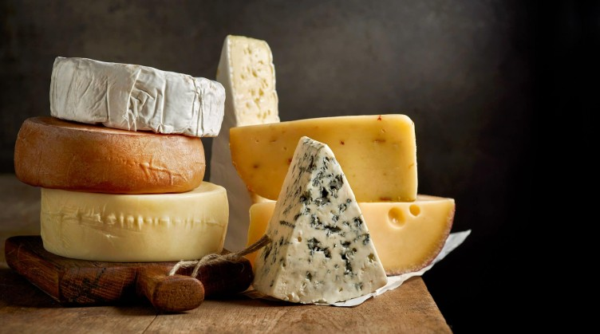

# 1. Introduction

We have been tasked with developing a system that can determine whether a cheese has a higher or lower fat content. To accomplish this, we will create a model through a process known as training in machine learning. The main objective of training is to produce a precise model that can accurately answer our questions most of the time. However, to train the model, we need to obtain data that we can use. This is where our journey begins.

We will be collecting data from the Canadian Cheeses dataset, which contains information on various aspects of cheese such as flavor and shape. For our purposes, we will focus on two straightforward factors: `the type of milk` used and `the percentage of moisture content`. We hope that by examining these two features alone, we can categorize our cheese samples into `higher` and `lower fat levels`. From this point on, we will refer to these features as `milk type` and `moisture`. We have gathered data from the following resources for our exploratory data analysis.

### Data Source and Overview

The original dataset can be accessed on the Government of Canada's Open Government Portal, under Open Data and Agriculture categories.

[Government of Canada's Open Government Portal](https://open.canada.ca/en) > [Open Data](https://open.canada.ca/en/open-data) > [Agriculture](https://search.open.canada.ca/en/od/?od-search-subjects=Agriculture&_ga=2.936695.774668073.1646111134-817596509.1646111134).

The UBC Data Science faculty conducted data wrangling and cleaning on the original dataset and provided us with a modified version of it.

The dataset, called `cheese_data`, is a table with 13 columns: `cheeseId`, `ManufacturerProvCode`, `ManufacturingTypeEn`, `MoisturePercent`, `FlavorEn`, `CharacteristicsEn`, `Organic`, `CategoryTypeEn`, `MilkTypeEn`, `MilkTreatmentTypeEn`, `RindTypeEn`, `CheeseName`, `FatLevel`, stored in a **.csv** file.

### Data schema

The columns in the dataset are:

- **CheeseId** : The unique Identification number for cheese.
- **ManufacturerProvCode** : The name of province produced the cheese.
- **ManufacturingTypeEn** : The type of manufacturing pocessed the cheese.
- **MoisturePercent** : The percentage of moisture contained in the cheese.
- **FlavorEn** : The flavor of the cheese.
- **CharacteristicsEn** : The chracteristic of the cheese.
- **Organic** : If the cheese is organic or not.(1 = Organic, 0 = Non-organic)
- **CategoryTypeEn** : The type of cheese in category.
- **MilkTypeEn** : The type of milk used for the cheese.
- **MilkTreatmentTypeEn** : The type of treatment the cheese had.
- **RindTypeEn** : The type of rind of the cheese.
- **CheeseName** : The name of the cheese.
- **FatLevel** : The fat level of the cheese.

For our prediction model, we will only utilize three columns: `Moisturepercent`, `MilkTypeEn`, and `FatLevel`.

# 2. Preprocessing Data through Cleaning

```python
# Import the necessary libraries for EDA
import pandas as pd
import altair as alt
import numpy as np

from sklearn import tree
from sklearn.model_selection import train_test_split, cross_validate
from sklearn.dummy import DummyClassifier
from sklearn.neighbors import KNeighborsClassifier
from sklearn.tree import DecisionTreeClassifier
from sklearn.ensemble import RandomForestClassifier
from sklearn.svm import SVC, SVR
from sklearn.linear_model import LogisticRegression
from sklearn.model_selection import GridSearchCV, RandomizedSearchCV
from sklearn.preprocessing import (FunctionTransformer, Normalizer, OneHotEncoder, StandardScaler, normalize, scale)
from sklearn.compose import ColumnTransformer, make_column_transformer
from sklearn.pipeline import Pipeline, make_pipeline
from sklearn.impute import SimpleImputer
from sklearn.feature_extraction.text import CountVectorizer
from sklearn.metrics import plot_confusion_matrix
from sklearn.metrics import confusion_matrix
from sklearn.metrics import accuracy_score, precision_score, recall_score, f1_score
from sklearn.metrics import classification_report
from sklearn.metrics import make_scorer
from scipy.stats import lognorm, loguniform, randint

# Import the cheese data file
cheese = pd.read_csv("data/cheese_data.csv")
```

After completing the setup, our initial task in machine learning is to gather data, which is a crucial step as the quality and quantity of the collected data will influence the accuracy of our predictive model. Our focus will be on collecting data regarding the `milk type` and `moisture content` for each cheese, which will enable us to create a table consisting of milk type, moisture content, and the cheese's fat content - **high** or **low**. This table will serve as our training data.

```python
# Obtain data from the cheese dataset
cheese_df = cheese.drop(columns=['CheeseId', 'Organic', 'ManufacturerProvCode', 'ManufacturingTypeEn', 'FlavourEn', 'CharacteristicsEn', 'CategoryTypeEn', 'MilkTreatmentTypeEn', 'RindTypeEn', 'CheeseName']).dropna()

# Display the first few rows of the obtained data
cheese_df.head()
```

|  | MoisturePercent | MilkTypeEn | FatLevel |
| --- | --- | --- | --- |
| 0 | 47.0 | Ewe | lower fat |
| 1 | 47.9 | Cow | lower fat |
| 2 | 54.0 | Cow | lower fat |
| 3 | 47.0 | Cow | lower fat |
| 4 | 49.4 | Cow | lower fat |

```python
# Display the dimension of the cheese data
cheese_df.shape
```

```
(1027, 3)
```

It's time for us to move on to the next phase of machine learning, which is data preparation. During this stage, we will load our data into a suitable location and prepare it for use in our machine learning training. Our first task will be to gather all of our data and randomize its order. Additionally, we will need to divide the data into two parts: the `Train set`, which will make up the majority of our dataset and be used to train our model, and the `Test set`, which will be used to evaluate the performance of our trained model.

```python
# Create feature vectors and target variable
X = cheese_df.drop(columns=["FatLevel"])
y = cheese_df["FatLevel"]

# Split the data into training and testing sets
X_train, X_test, y_train, y_test = train_test_split(X, y, test_size=0.3, random_state=123)

# Print the head of the training set
X_train.head()
```

|  | MoisturePercent | MilkTypeEn |
| --- | --- | --- |
| 687 | 54.0 | Cow |
| 885 | 55.0 | Goat |
| 861 | 46.0 | Cow |
| 967 | 39.0 | Cow |
| 940 | 42.0 | Goat |

The code above creates feature vectors and a target variable from the "cheese_df" DataFrame. The feature vectors are stored in a DataFrame called "X", which includes all columns except for "FatLevel". The target variable is stored in a Series called "y", which includes only the "FatLevel" column.

The train_test_split() function is then used to split the data into `training` and `testing sets`, with a test size of 0.3 and a random state of 123. The training data is stored in "X_train" and "y_train", while the testing data is stored in "X_test" and "y_test".

```python
# Print the shape of the training set
X_train.shape
```

```
(718, 2)
```

# 3. Analysis of Data through Descriptive Statistics

We'll check to see if there are any noteworthy findings in the `X_train` dataset.

```python
# Generate summary statistics for the dataframe
X_train.describe()
```

|  | MoisturePercent |
| --- | --- |
| count | 718.000000 |
| mean | 47.083705 |
| std | 9.785916 |
| min | 20.000000 |
| 25% | 40.000000 |
| 50% | 46.000000 |
| 75% | 52.000000 |
| max | 92.000000 |

```python
# Display information about the dataframe
X_train.info()
```

```
<class 'pandas.core.frame.DataFrame'>
Int64Index: 718 entries, 687 to 111
Data columns (total 2 columns):
 #   Column           Non-Null Count  Dtype
---  ------           --------------  -----
 0   MoisturePercent  718 non-null    float64
 1   MilkTypeEn       718 non-null    object
dtypes: float64(1), object(1)
memory usage: 16.8+ KB
```

# 4. Representation of Data through Visualization

At this point, it would be beneficial to create data visualizations to identify any significant relationships between variables and detect any data imbalances that may exist.

```python
# Create a data visualization chart
cheese_plot1 = alt.Chart(cheese_df, width=500, height=300).mark_point().encode(
    x='MoisturePercent',
    y='FatLevel',
    color='FatLevel',
    tooltip=['FatLevel']
).interactive().properties(title='The relationship between moisture and fat level')

# Display the chart
cheese_plot1
```

[interactive chart not shown]

The chart is a scatter plot that shows the relationship between `the moisture percentage` and `fat level` of different types of cheese.

The x-axis represents the moisture percentage, while the y-axis represents the fat level. Each data point is colored based on its fat level, and hovering over a point will display the fat level value in a tooltip.

The chart is interactive, allowing the user to zoom and pan to explore the data. It also includes a title that describes the purpose of the chart.

```python
# Create a supporting data visualization chart
cheese_plot2 = alt.Chart(cheese_df, width=500, height=300).mark_point().encode(
    x='MilkTypeEn',
    y='FatLevel',
    color='FatLevel',
    tooltip=['FatLevel']
).interactive().properties(title='The relationship between milk type and fat level')

# Display the chart
cheese_plot2
```

[interactive chart not shown]

The chart is a scatter plot that shows the relationship between `the type of milk` used and `the fat level` of different types of cheese.

The x-axis represents the type of milk used in the cheese, while the y-axis represents the fat level. Each data point is colored based on its fat level, and hovering over a point will display the fat level value in a tooltip.

# 5. Assessment of Classification Models in Machine Learning

The subsequent stage in our workflow is to select a suitable model from a variety of options available to researchers and data scientists.

In our case, since we have only two features, `milk type` and `moisture percentage`, and a categorical predicted (target) value indicating either **"higher fat"** or **"lower fat"**, we can employ a `classification model` to predict the target value.

Take into account the following machine learning tasks:

#### Is there a correlation between fat content and moisture level, and does this correlation vary depending on the type of milk being analyzed?

The output for each scenario is binary, with Yes or No being the possible outcomes. Positive outcomes are typically assigned the value of 1, while negative outcomes are represented by 0.

```python
# Identify the numeric, categorical, and binary columns
numeric_feats = ["MoisturePercent"]
categorical_feats = ["MilkTypeEn"]

# Preprocessing for numerical data: Impute missing values with median and scale features
numeric_transformer = make_pipeline(SimpleImputer(strategy='median'),
                                    StandardScaler()
                                   )

# Preprocessing for categorical data: Impute missing values with most frequent and encode categories as one-hot
categorical_transformer = make_pipeline(SimpleImputer(strategy='most_frequent', fill_value='missing'),
                                        OneHotEncoder(handle_unknown="ignore")
                                   )

# Combine preprocessing steps using ColumnTransformer
preprocessor = make_column_transformer(
                (numeric_transformer, numeric_feats),
                (categorical_transformer, categorical_feats),
                remainder="passthrough")
```

### 5-1. Dummy Classifier

A dummy classifier is a type of classifier that makes predictions using simple rules, rather than using a complex model. It is typically used as a baseline for comparison to more sophisticated models, as it can provide insight into the performance of a model that simply guesses randomly.

A dummy classifier may be used as a point of reference to measure the effectiveness of a more advanced model.

```python
# Create the beseline model
dummy_clf = DummyClassifier(strategy="prior")

# Calculate cross-validation scores for the baseline model.
dummy_scores = pd.DataFrame(cross_validate(dummy_clf, X_train, y_train, cv=5, return_train_score=True))
dummy_scores
```

|  | fit_time | score_time | test_score | train_score |
| --- | --- | --- | --- | --- |
| 0 | 0.004391 | 0.004534 | 0.652778 | 0.651568 |
| 1 | 0.002260 | 0.002185 | 0.652778 | 0.651568 |
| 2 | 0.002279 | 0.001087 | 0.652778 | 0.651568 |
| 3 | 0.003698 | 0.005693 | 0.650350 | 0.652174 |
| 4 | 0.002368 | 0.001239 | 0.650350 | 0.652174 |

The code above creates a baseline model using the DummyClassifier from scikit-learn with the strategy parameter set to "prior". This strategy always predicts the most frequent class in the training set.

The cross_validate function from scikit-learn is used to calculate cross-validation scores for the baseline model. The function performs 5-fold cross-validation (cv=5) and returns **training** and **testing scores** for each fold.

The resulting scores are stored in a pandas DataFrame called `dummy_scores`. The DataFrame contains columns for the **training** and **testing scores** for each fold, as well as columns for the **fit** and **score times**.

```python
mean_dummy_training_score = dummy_scores['train_score'].mean()
mean_dummy_cv_score = dummy_scores['test_score'].mean()

mean_dummy_scores = pd.DataFrame({'Mean': ['training_score', 'cv_score'],
                                 'Scores': [mean_dummy_training_score, mean_dummy_cv_score]
                                 })
mean_dummy_scores
```

|  | Mean | Scores |
| --- | --- | --- |
| 0 | training_score | 0.651810 |
| 1 | cv_score | 0.651807 |

"The score of our dummy classifier ranges from **65%**"

### 5-2. Random Forest Classifier

Random forest classifier is a type of ensemble learning method that creates a large number of decision trees and combines their predictions to make more accurate predictions.

The Random Forest Classifier is a useful tool for quickly identifying significant information from large datasets. One of its key advantages is that it aggregates multiple decision trees to arrive at a solution, which can lead to better accuracy compared to other classification algorithms.

```python
# Create the main pipeline with preprocessor and Random Forest Classifier
main_pipe = make_pipeline(preprocessor, RandomForestClassifier(random_state=77, class_weight='balanced'))

# Calculate the scores of the main pipeline using cross-validation
scores_df = pd.DataFrame(cross_validate(main_pipe, X_train, y_train, cv=5, return_train_score=True))
scores_df
```

|  | fit_time | score_time | test_score | train_score |
| --- | --- | --- | --- | --- |
| 0 | 0.333828 | 0.036371 | 0.833333 | 0.862369 |
| 1 | 0.252244 | 0.022920 | 0.805556 | 0.865854 |
| 2 | 0.247132 | 0.022925 | 0.833333 | 0.871080 |
| 3 | 0.256660 | 0.023254 | 0.811189 | 0.866087 |
| 4 | 0.246029 | 0.034455 | 0.783217 | 0.871304 |

```python
mean_rfc_training_score = scores_df['train_score'].mean()
mean_rfc_cv_score = scores_df['test_score'].mean()

mean_rfc_scores = pd.DataFrame({'Mean': ['training_score', 'cv_score'],
                                 'Scores': [mean_rfc_training_score, mean_rfc_cv_score]
                               })
mean_rfc_scores
```

|  | Mean | Scores |
| --- | --- | --- |
| 0 | training_score | 0.867339 |
| 1 | cv_score | 0.813326 |

"The score of our random forest classifier ranges from **81%** to **86%**."

### 5-3. Evaluating Classification Models

Consequently, the `Random Forest Classifier` model outperforms the `Dummy Classifier` model.

Machine learning algorithms have hyperparameters that can be adjusted to optimize their performance on a particular dataset. When the number of dimensions is small, `RandomizedSearchCV` is considered the most effective parameter search technique.

```python
# Tuning the hyperparameters
param_grid = {
    "randomforestclassifier__max_depth": range(1,101,10)
}

depth_search = RandomizedSearchCV(main_pipe, param_grid, cv=5, n_iter=5, return_train_score=True, random_state=77, verbose=2)
depth_search.fit(X_train, y_train)
```

```
Fitting 5 folds for each of 5 candidates, totalling 25 fits
[CV] END ...............randomforestclassifier__max_depth=21; total time=   0.3s
[CV] END ...............randomforestclassifier__max_depth=21; total time=   0.3s
[CV] END ...............randomforestclassifier__max_depth=21; total time=   0.3s
[CV] END ...............randomforestclassifier__max_depth=21; total time=   0.3s
[CV] END ...............randomforestclassifier__max_depth=21; total time=   0.3s
[CV] END ...............randomforestclassifier__max_depth=11; total time=   0.3s
[CV] END ...............randomforestclassifier__max_depth=11; total time=   0.3s
[CV] END ...............randomforestclassifier__max_depth=11; total time=   0.3s
[CV] END ...............randomforestclassifier__max_depth=11; total time=   0.3s
[CV] END ...............randomforestclassifier__max_depth=11; total time=   0.3s
[CV] END ...............randomforestclassifier__max_depth=91; total time=   0.3s
[CV] END ...............randomforestclassifier__max_depth=91; total time=   0.3s
[CV] END ...............randomforestclassifier__max_depth=91; total time=   0.3s
[CV] END ...............randomforestclassifier__max_depth=91; total time=   0.3s
[CV] END ...............randomforestclassifier__max_depth=91; total time=   0.3s
[CV] END ...............randomforestclassifier__max_depth=61; total time=   0.3s
[CV] END ...............randomforestclassifier__max_depth=61; total time=   0.3s
[CV] END ...............randomforestclassifier__max_depth=61; total time=   0.3s
[CV] END ...............randomforestclassifier__max_depth=61; total time=   0.3s
[CV] END ...............randomforestclassifier__max_depth=61; total time=   0.3s
[CV] END ................randomforestclassifier__max_depth=1; total time=   0.2s
[CV] END ................randomforestclassifier__max_depth=1; total time=   0.2s
[CV] END ................randomforestclassifier__max_depth=1; total time=   0.2s
[CV] END ................randomforestclassifier__max_depth=1; total time=   0.3s
[CV] END ................randomforestclassifier__max_depth=1; total time=   0.2s
```

```
RandomizedSearchCV(cv=5,
                   estimator=Pipeline(steps=[('columntransformer',
                                              ColumnTransformer(remainder='passthrough',
                                                                transformers=[('pipeline-1',
                                                                               Pipeline(steps=[('simpleimputer',
                                                                                                SimpleImputer(strategy='median')),
                                                                                               ('standardscaler',
                                                                                                StandardScaler())]),
                                                                               ['MoisturePercent']),
                                                                              ('pipeline-2',
                                                                               Pipeline(steps=[('simpleimputer',
                                                                                                SimpleImputer(fill_value='missing',
                                                                                                              strategy='most_frequent')),
                                                                                               ('onehotencoder',
                                                                                                OneHotEncoder(handle_unknown='ignore'))]),
                                                                               ['MilkTypeEn'])])),
                                             ('randomforestclassifier',
                                              RandomForestClassifier(class_weight='balanced',
                                                                     random_state=77))]),
                   n_iter=5,
                   param_distributions={'randomforestclassifier__max_depth': range(1, 101, 10)},
                   random_state=77, return_train_score=True, verbose=2)
```

```python
# Store the grid search results in a dataframe
grid_results = pd.DataFrame(depth_search.cv_results_, columns=['mean_test_score', 'param_randomforestclassifier__max_depth', 'mean_fit_time', 'rank_test_score'])
grid_results = grid_results.sort_values(by='rank_test_score')

grid_results
```

|  | mean_test_score | param_randomforestclassifier__max_depth | mean_fit_time | rank_test_score |
| --- | --- | --- | --- | --- |
| 0 | 0.813326 | 21 | 0.280368 | 1 |
| 1 | 0.813326 | 11 | 0.275888 | 1 |
| 2 | 0.813326 | 91 | 0.263958 | 1 |
| 3 | 0.813326 | 61 | 0.262938 | 1 |
| 4 | 0.806352 | 1 | 0.200702 | 5 |

```python
# Find the best parameters and scores
best_parameters = depth_search.best_params_
best_score = depth_search.best_score_
print("Best parameters:", best_parameters)
print("Best score:", best_score)
```

```
Best parameters: {'randomforestclassifier__max_depth': 21}
Best score: 0.8133255633255633
```

Based on the hyperparameter tuning, the best `max_depth` value for the `random forest classifier` is **21**, and the best `cross-validation accuracy` score achieved is **0.8133255633255633**.

```python
# Find the best model
best_model = depth_search.best_estimator_
best_model
```

```
Pipeline(steps=[('columntransformer',
                 ColumnTransformer(remainder='passthrough',
                                   transformers=[('pipeline-1',
                                                  Pipeline(steps=[('simpleimputer',
                                                                   SimpleImputer(strategy='median')),
                                                                  ('standardscaler',
                                                                   StandardScaler())]),
                                                  ['MoisturePercent']),
                                                 ('pipeline-2',
                                                  Pipeline(steps=[('simpleimputer',
                                                                   SimpleImputer(fill_value='missing',
                                                                                 strategy='most_frequent')),
                                                                  ('onehotencoder',
                                                                   OneHotEncoder(handle_unknown='ignore'))]),
                                                  ['MilkTypeEn'])])),
                ('randomforestclassifier',
                 RandomForestClassifier(class_weight='balanced', max_depth=21,
                                        random_state=77))])
```

Upon completion of hyperparameter tuning, we will receive the pipeline object containing the most favorable amalgamation of hyperparameters.

```python
# Print classification report
report = classification_report(y_test, best_model.predict(X_test))
print(report)
```

```
              precision    recall  f1-score   support

  higher fat       0.74      0.65      0.69       105
   lower fat       0.83      0.88      0.86       204

    accuracy                           0.80       309
   macro avg       0.78      0.76      0.77       309
weighted avg       0.80      0.80      0.80       309
```

```python
# Evaluate the accuracy score of the best model on the test set
test_score = best_model.score(X_test, y_test)
test_score
```

```
0.8025889967637541
```

The final test score on the best model is **0.8025889967637541**.

```python
# Make predictions using the best model
tr_pred = depth_search.predict(X_train)
ts_pred = depth_search.predict(X_test)
```

At this point, we have trained a `Random Forest Classifier` model on the cheese dataset, tuned its hyperparameters using `Randomized Search Cross Validation`, and evaluated its performance using `accuracy score` and classification report. We also made predictions on the training and test sets.

```python
# Perform probability using the model
tr_prob = best_model.predict_proba(X_train)
ts_prob = best_model.predict_proba(X_test)
```

### 5-4. Confusion Matrix

A `confusion matrix` is a table used to evaluate the performance of a machine learning model for classification problems. It summarizes the number of correct and incorrect predictions made by the model on a set of test data.

The matrix consists of four terms: True Positive (TP), False Positive (FP), True Negative (TN), and False Negative (FN).

- True Positive (TP): The model correctly predicts the positive class.
- False Positive (FP): The model incorrectly predicts the positive class.
- True Negative (TN): The model correctly predicts the negative class.
- False Negative (FN): The model incorrectly predicts the negative class.

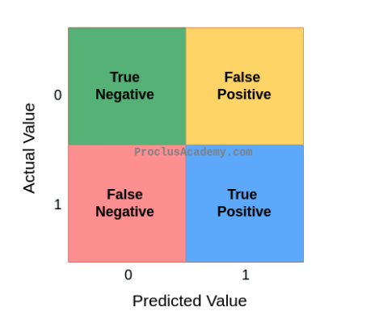

```
<sklearn.metrics._plot.confusion_matrix.ConfusionMatrixDisplay at 0x7f96427fc370>
```

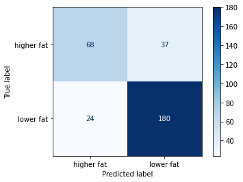

```python
# Plot the confusion matrix for the best model on the test set
plot_confusion_matrix(best_model, X_test, y_test, values_format="d", cmap="Blues")
```

# 6. Accuracy

**Accuracy** is the simplest metric to measure the performance of a classification model. It answers the below question:

**What percentage of predictions did the model get right?**

We know that True Positives and True Negatives are the outcomes when the expected result matches the model prediction. Their sum is the total number of correct outcomes. We divide this count by the total number of predictions to get the **Accuracy**.

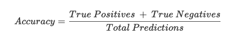

Our model's accuracy can be stated as **80%**.

# 7. Remarks

According to Cross-validation, `RandomForestClassifier` model performs better than `DummyClassifier` model.

The final test score on the best model is **0.8025889967637541**.

Besides, the `CountVectorizer()` transformer could be used in our pipeline with the `LogisticRegression` model for better outcomes by comparison with current models.

# 8. References

- Image: Confusion Matrix. [Link](https://ProclusAcademy.com)